#### 関数の利用

```r
model_selection <- bayes_stay_selection(
  formula_stay = Stay ~ 1 + x1, # 滞在時間のモデル式
  station_data = station_data_comprad,  # add_effort関数の返り値
  stay_data = stay_data,        # format_stay関数の返り値
  family = "lognormal",         # 滞在時間分布
  local_stay = TRUE,            # 上で説明
  plot = TRUE,                  # 滞在時間の期待値を可視化するか
  cores = 3,                    # 計算に利用するコア数
  iter = 3000,                  # iteration数
  warmup = NULL,                # warmup数
  chains = 3,                   # チェーン数
  thin = 1,                     # thinningの間隔
  all_comb = TRUE               # 上で説明
)
```

```
## Stay~1 [lognormal]
## Now compiling!
##
## MCMC sampling start.
## Stay~1 + x1 [lognormal]
## Now compiling!

## recompiling to avoid crashing R session

##
## MCMC sampling start.
```

```r
model_selection
```

```
## $result
##           Model    Family     lppd p_waic    WAIC
## 1      Stay ~ 1 lognormal -2523.53   1.97 5051.00
## 2 Stay ~ 1 + x1 lognormal -2523.54   2.98 5053.04
##
## $plot
```

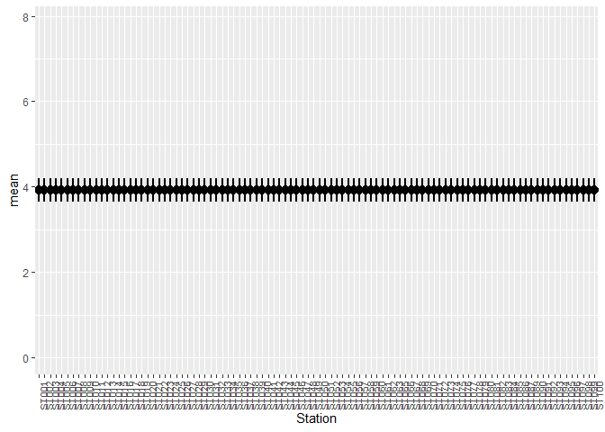

WAIC値を比較すると，ほとんど差がありません．このような場合はシンプルなモデルを選択すればよいでしょう．他の確率分布を試したい場合は，family引数で指定してください．

### 密度推定のための関数

滞在時間のモデル選択が出来たらいよいよ密度推定です．

密度をベイズ推定する関数は，**bayes_rest関数**です．以下のように，必要な変数を指定するだけで密度が推定できます．まず，関数の全引数を示します．

[output not shown]

**bayes_rest関数の引数一覧．太字の引数については以下で説明．*の意味については，一般的なMCMC法によるベイズ推定に関する書籍やサイトを参考にしてください．**

#### 活動時間割合に関わる引数

活動時間割合の推定方法を指定するのがactivity_moel引数です．２つの方法が利用可能です．

**activity = “kernel”**とした場合，固定カーネル法による推定を行います．詳細は，Rowcliffe et al. (2014)を参照してください．この推定方法を用いる場合，バンド幅の調整方法を指定するbw_adj引数も同時に指定できます．デフォルト値は，Rowcliffe et al. (2014)の論文のシミュレーション結果に基づいて1.5にしています．特別な事情がない限り，デフォルト値のままでよいでしょう．

**activity = “mixed”**とした場合，撮影時間をvon Mises混合分布に従う確率変数であると考えます．混合分布では，何個の確率分布を混ぜ合わせるかが問題になります．それを指定するのがK引数です．Kのデフォルト値は5にしています．経験的には，大体この値で対処できるようです．Kの値を大きくすればその分だけ推定に要する時間が長くなります．あまり小さいと，うまく活動レベルの変動にフィットしなくなります[^9]．

２つの推定手法にはいくつかの点で顕著な違いがあります．

１つ目の違いは，不確実性の評価に関してです．混合von Mises分布を利用した方法では，他の変数と同様にパラメータのベイズ推定を行います．活動時間割合も点推定値ではなく，不確実性を含んだ値として扱われます．一方で，固定カーネル法の方はRowcliffe et al. (2014)が作成したactivityパッケージの点推定値をそのまま定数として入れています．したがって，密度の見た目上の推定精度は，固定カーネル法を利用した方が良くなります．

２つ目は，推定に要する時間の違いです．一般に混合分布のパラメータ推定には非常に時間がかかります．MCMCで混合分布を解くのは結構しんどいことと，Stanのvon Mises分布の確率密度関数（von_mises_lpdf）がベクトル化に対応していないことが原因です．推定結果が出るまでに数十分はかかると思ってください．一方，カーネル法は定数として入れるので，それに比べるとはるかに速いです（最尤推定よりは遅い）．

３つ目は，推定のバイアスに関する違いです．Rowcliffe et al. (2014)は，von Mises混合分布を利用した方法は，サンプルサイズが小さい場合（50未満），活動時間割合を過小評価する（密度は過大評価される）傾向があると指摘しています．同様の傾向を私も確認しています．あまり気にする必要はありませんが，推定値を比較する場合には少し注意が必要です．

これらの違いを踏まえたうえで，どちらの方法を使うかを判断してください．活動時間割合のパラメータだけ定数で入れるのはなんとなく気持ち悪いので混合分布を実装しましたが[^10]，必ずしもお勧めしません．推定にかかる時間を考えると，少なくとも試行錯誤の段階では固定カーネル法の方が良いでしょう．そして解析の最終段階で．混合分布の利用を考えてみるのも一つの手です．いずれにせよ，活動時間割合の推定は，REST/RAD-RESTを含む，無標識個体群のための密度推定手法の最大の弱点です．どちらの方法も抱えている弱点（仮定の強さ）は同じなので，こだわりすぎる必要はありません．